[figure not shown]

# Projeto final - Estudo da rede de metro londrina

**Curso de Licenciatura em Ciência dos Dados**

**U.C.: Estruturas de Dados e Algoritmos**

**Docente**: Ana Maria Almeida

**Aluno**: Ricardo E. Santo, nº 93357

**Aluno**: Rodrigo Sarroeira, nº 92761

**07 de Junho de 2020**

## Índice

1. Introdução
2. Fundamentos teóricos

   2.1. Bisseção Espectral (Spectral Bisection)

   2.2. Algoritmo de Dijkstra
1. Solução produzida

   3.1. Estruturas de base (g12_structures)

   3.2. Estrutura do grafo para fase 1 (g12_metro_fase1)

   3.3. Estrutura do grafo para fase 2 (g12_metro_fase2)

   3.4. Código para o método Spectral Bissection ( g12_min_cut_graph )

   3.5. Código para o algoritmo de Dijkstra ( g12_dijkstra )

   3.6. Código "Maestro" ( g12_main )
1. Resultados obtidos
2. Visualização dos resultados
3. Discussão dos resultados obtidos
4. Bibliografia

## Introdução

No projeto final de EDA o objetivo nesta primeira fase foi de determinar quão robusta é a rede de metro Londres, o que corresponde a analisar um grafo da rede e determinar qual o número mínimo de arestas a remover, com o intuito de separar o grafo correspondente a rede de metro em duas partes independentes e de uma dimensão significativamente aproximada conservando a interconexão dentro de cada grafo produzido. Para este fim foi necessário implementar um tipo abstrato de dados (TAD) grafo com métodos de consulta, inserção, remoção e pesquisa, com aplicação prática nesta fase do problema, usando dados abertos sobre a rede de metropolitano de Londres foi possível determinar as estações(vértices do grafo) e as conexões entre estações(arestas do grafo). No nosso caso de estudo, ao dividir a rede em duas, esta divisão deve garantir que as sub-redes tinham um número significativo de interconexões.

Para atingir este propósito o algoritmo da Bisseção Espectral( *Spectral Bissection* ) foi utilizado, com este algoritmo foi possível atingir todos os propósitos determinados na primeira fase. O resultado deste algoritmo forneceu uma divisão proporcional em dois grafos robustos bem como a determinação do corte mínimo de arestas para este objetivo. Verificando estes resultados na minimização do *ratio cut partition* que corresponde ao rácio entre o número de cortes e o produto da cardinalidade de elementos em ambos os grafos.

Na segunda fase do projeto, o objetivo foi de determinar o caminho ótimo entre duas estações (vértices) da linha de metro (grafo). O caminho ótimo é aquele que tem o menor custo (peso da aresta, neste caso minutos) entre estações, sem repetir estações. Este tempo de viagem tem três periodos horários do dia: " Off Peak Running Time (mins )", " AM peak (0700 - 1000) Running Time (mins )", " Inter peak (1000 - 1600) Running time (mins)". Para calcular o tempo total da viagem foi necessário contabilizar os tempos de comutação da linha, considerando 10 mins o tempo de troca. Utilizamos para a resolução deste problema o algoritmo de *Dijkstra* . Este algoritmo é um dos algoritmos mais populares na ciência da computação. É também popular na investigação operacional. É geralmente visto e apresentado como um greedy algorithm [1].

## Fundamentos teóricos

O TAD grafo é uma estrutura que pode representar na perfeição uma rede de metro como a Londres, para esse efeito é produzida a abstração na qual o grafo não orientado **G** corresponde a rede de metro de Londres. Em **G** temos dois tipos de constituintes, estações **V** que serão os vértices do grafo e ligações entre estações **E** arestas de **G** . O preenchimento sequencial das linhas de **G** consiste na colocação de um valor de 1 para coluna do vértice que estabelece uma ligação com o vértice da linha e 0 para os casos contrários. Após a produção desta estrutura temos o grafo **G( V, E )** para aplicar sobre o mesmo um método de partição em duas subestruturas. O critério de partição do grafo em dois tem por meta a subdivisão em dois grafos ( $ G_1 $ e $ G_2 $ ) de cardinalidades aproximadas e o menor valor de arestas do grafo cortadas (**c**) para esta solução.

$$ f = \frac{c}{|G_1|*|G_2|} $$

A minimização do valor de *f* corresponde ao corte do grafo por aquilo que é conhecido como *"ratio cut partition"* . A resolução deste problema numérico de minimização não é de fácil solução no entanto é possível atingir uma solução adequada para este problema recorrendo ao algoritmo da **Spectral Bissection** [2]

### Bisseção Espectral (Spectral Bisection)

O algoritmo de bissecção não utiliza informação geométrica nem opera sobre o grafo em si, utilizando a sua representação matemática na forma matricial. O foco deste método está em operações com valores em formato de vírgula flutuante (float) e com vetores. A abordagem à divisão do grafo tem em consideração todo o grafo e deste modo uma abordagem global do problema. Este método tem uma explicação simples na sua aplicação, mas a razão pela qual a solução heurística funciona não é óbvia.[3]

De uma forma abreviada este algoritmo de partição, tem como base o grafo **G( V, A )** produzindo uma matriz de adjacências **A(V)** o que corresponde no caso deste grafo não orientado a uma matriz quadrada simétrica. Em que as linhas e as colunas de **A** são os vértices com igual ordenação, ou seja, as estações de metro, e no caso de existir uma aresta, i.e., uma ligação entre estações esta situação é identificada pelo valor de 1 e em caso contrário o valor 0.

Com **A(V)** é elaborada a matriz de grau **D** , com as mesmas dimensões de **A**, em que nos elementos da diagonal tem o somatório de todos os elementos da linha de **A** desse vértice e os restantes valores são 0. Finalmente é elaborada uma matriz Laplaciana **L** através das duas anteriores entidades [3].

$$ L= D-A $$

Com recurso aos valores próprios e vetores próprios de **L** é possível elaborar a partição em $G_1$ e $G_2$. Os valores próprios de **L** não negativos vão fornecer informação sobre a conetividade dos elementos do grafo. O menor valor próprio não nulo é chamado de " Spectral gap " e fornece a noção da densidade do gráfico. O seu valor seria tanto maior consoante o grafo estivesse densamente ligado com arestas a interligar-se entre todos os outros vértices.

O segundo menor valor próprio denomina-se de "*Fiedler value*" ou valor de Fiedler representado por $ \lambda_1 $, e o vetor próprio correspondente a $ \lambda_1 $ é o vetor de Fiedler $ v_1 $ ou $ v_{Fiedler}$. O valor de Fiedler aproxima-se da noção de conectividade algébrica e permite abordar a problemática do corte mínimo do gráfico necessário para separar o grafo em dois componentes ligados preservando a conectividade. Cada valor no vetor de Fiedler dá-nos informação sobre qual a partição a que o nó pertence, uma separação por sinal positivo e caso contrário dos vértices correspondentes aos valores do vetor é um critério de separação em grafos [5]. Com a produção de um vetor de sinal $ v_{sinal} $ tendo como base o vector de Fiedler e a conversão dos valores negativos do mesmo em -1 e os restantes em +1. Esta distribuição de sinal é possível verificar na figura 1.

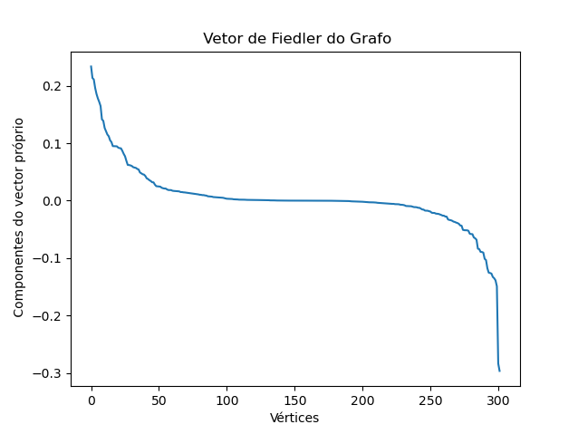

Figura 1 - Distribuição do sinal dos componentes do $v_{Fidler}$

Como é possível verificar do nosso $ v_{Fiedler}$ ordenado, a distribuição dos valores é quase sinusoidal e balançada em termos de sinal [6]. O valor do corte mínimo de arestas, **c** para a subdivisão do grafo **G** nesta abordagem poderá ser calculada aplicando a seguinte expressão:

$$ c = \frac{1}{4}*v_{sinal}*L*v_{sinal^T} $$

Com a resolução do problema numérico de uma forma heurística é assim determinada uma solução ótima ou a mais próxima da ótima para a subdivisão do grafo **G**.

### Algoritmo de Dijkstra

Na nossa implementação deste algoritmo, com vista a encontrar o caminho ótimo, seguimos os seguintes passos:

**Passo 0:** Verificar se a estação de partida é igual à estação de chegada, nesse caso terminar o algoritmo.

**Passo 1:** Produção de um TAD grafo **unvisited** , implementado através de um dicionário, com o objetivo de guardar todos os vértices não visitados e as respectivas conexões que os ligam. A sua finalidade é de determinar a paragem do algoritmo. Criação de outro dicionário ( *track_prodecessor* ) no qual as chaves correspondem aos vértices percorridos e os valores a estas associados são os vértices anteriores a estes. Esta estrutura vai permitir numa fase posterior realizar o *Backtracking* do caminho ótimo.

**Passo 2:** Criação de um dicionário (**shortest_dist**)cujas chaves são os valores pertencentes a lista dos não visitados (todos os vértices do grafo). Os valores correspondentes a cada chave ( *i* ) representam a distância (tempo) entre o vértice de partida e os vértices i.

**Passo 3:** No dicionário anteriormente referido, os valor da chave correspondente ao vértice de partida é colocado a zero e os restantes com o valor de infinito (dado não existir nenhuma informação sobre a distância até esses vértices).

**Passo 4:** Enquanto existirem vértices por visitar no grafo **m2** :

**Passo 4.1:** Escolher o vértice que apresenta a menor distância e defini-lo como o vértice atual ( *current* ).

**Passo 5:** Definir o vértice de destino ( *end* ) como o vértice atual ( *current* ). Realizar o *Backtracking* enquanto o vértice *current* for diferente do vértice de partida ( *start* ).

**Passo 6:** Caso todas as chaves existam no *track_prodecessor* e seja atingido o vértice de partida, o algoritmo devolve o caminho ótimo.

## Solução produzida

Para melhor entendimento do código desenvolvido decidimos dividi-lo em vários módulos com encadeamento lógico. Estas partes estão sequêncialmente representadas na figura 2, onde podem ser encontradas as classes dentro de cada um dos módulos. Existem 6 ficheiros de código, cada um com o seu objetivo:

```python
# show results part 1
results_p1 = True

# show results part 2
results_p2 = True

# graph part 1
graph_1 = True

# graph part 2
graph_2 = True
```

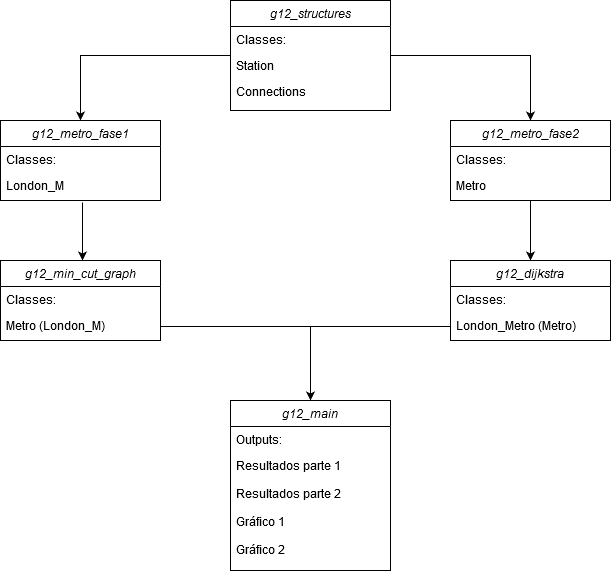

Figura 2 - Representação esquematica do código.

Para representar a linha de metro utilizando um grafo, vai ser necessária a criação de 3 classes. A primeira classe define as estações (vértices) e guarda todas as suas informações. A classe “Stations” possui um conjunto de métodos de consulta das propriedades.

### Estruturas de base (g12_structures)

```python
# Class Station ________________________________________________________________________________________________________


class Station:

    def __init__(self, id_s, latitude, longitude, name, display_name, zone, total_lines, rail):
        self._id = id_s
        self._latitude = latitude
        self._longitude = longitude
        self._name = name
        self._display_name = display_name
        self._zone = zone
        self._total_lines = total_lines
        self._rail = rail

    def get_id(self):
        return self._id

    def get_latitude(self):
        return self._latitude

    def get_longitude(self):
        return self._longitude

    def get_name(self):
        return self._name

    def get_display_name(self):
        return self._display_name

    def get_zone(self):
        return self._zone

    def get_total_lines(self):
        return self._total_lines

    def get_rail(self):
        return self._rail
```

A classe seguinte a ser produzida é a classe Connections que vai conter os vértices do grafo com informações das estações ligadas bem como outras propriedades sobre a ligação para futuras aplicações.

```python
# Class Connections ____________________________________________________________________________________________________


class Connections:

    def __init__(self, st1, st2, line=None, time=None):
        self._st1 = st1
        self._st2 = st2
        self._line = {line}
        self._time = [time]

    def get_time(self):
        return self._time

    def get_line(self):
        return self._line

    def get_st1_st2(self):
        return [self._st1, self._st2]

    def get_start(self):
        return self._st1

    def get_end(self):
        return self._st2

    def opposite(self, st):
        if st == self._st1:
            return self._st2
        if st == self._st2:
            return self._st1
        else:
            raise Exception('The station you are looking for does not exist')

    def get_time_average(self):
        t_sum1, t_sum2, t_sum3 = 0, 0 , 0
        for time_tuple in self._time:
            t_sum1, t_sum2, t_sum3 = t_sum1 + time_tuple[0], t_sum2 + time_tuple[1], t_sum3 + time_tuple[0]
        n = len(self._time)
        self._time = [(t_sum1/n, t_sum2/n, t_sum3/n)]
# ______________________________________________________________________________________________________________________
```

### Estrutura do grafo para fase 1 (g12_metro_fase1)

Em seguida a classe London_M é a base do grafo com operação de adição de Stations (vértices do grafo) e a adição de Connections (arestas do grafo). Armazenando estas estruturas num dicionário para operações e desenvolvimento do grafo.

```python
from g12_structures import Station
from g12_structures import Connections


class London_M:

    def __init__(self):
        self._graph = {}                # criar dicionário
        self._station = 0               # contador de estações
        self._connections = 0           # contador de conecções
        self.rawData = {}               # guarda informações sobre as stations

    def add_station(self, id_s, latitude, longitude, name, display_name, zone, total_lines, rail):
        if id_s not in self._graph.keys():
            station = Station(id_s, latitude, longitude, name, display_name, zone, total_lines, rail)

            self._graph[station.get_id()] = set([])
            self.rawData[station.get_id()] = station
                                        # adicionar a estação ao dicionário
            self._station = self._station + 1

    def add_connection(self, st1, st2, line=None, time=None):

        con = Connections(st1, st2, line, time)  # criar objeto do tipo Connections
        self._graph[st1].add(con)                # adicionar à lista da estação 1
        self._graph[st2].add(con)                # adicionar à lista da estação 2
        self._connections = self._connections + 1
```

### Estrutura do grafo para fase 2 (g12_metro_fase2)

Em seguida a classe Metro é a base do grafo com operação de adição de Stations (vértices do grafo) e a adição de Connections (arestas do grafo). Armazenando estas estruturas em dois dicionários para operações e desenvolvimento do grafo.

```python
from g12_structures import Station
from g12_structures import Connections


# Class Metro __________________________________________________________________________________________________________


class Metro:

    def __init__(self):
        self.graph = {}             # criar dicionário
        self._station = 0           # contador de estações
        self._connections = 0       # contador de conecções
        self.rawData = {}           # guarda informações sobre as stations
        self.graph1 = {}            # necessário para calcular o tempo ótimo

    def add_station(self, id_s, latitude, longitude, name, display_name, zone, total_lines, rail):
        if id_s not in self.graph.keys():
            station = Station(id_s, latitude, longitude, name, display_name, zone, total_lines, rail)
            self.graph[station.get_id()] = set([])

            self.rawData[station.get_id()] = station
                                            # adicionar a estação ao dicionário
            self._station = self._station + 1

        if id_s not in self.graph1.keys():
            station = Station(id_s, latitude, longitude, name, display_name, zone, total_lines, rail)
            self.graph1[station.get_id()] = set([])

    def add_connection(self, st1, st2, line=None, time=None):

        con = Connections(st1, st2, line, time)     # criar objeto do tipo Connections
        self.graph[st1].add(con)                    # adicionar à lista da estação 1
        self.graph1[st1].add(con)
        con = Connections(st2, st1, line, time)
        self.graph[st2].add(con)                    # adicionar à lista da estação 2
        self.graph1[st2].add(con)
        self._connections = self._connections + 1
```

### Código para o método Spectral Bissection ( g12_min_cut_graph )

Herdando a estrutura da classe London_M, que é o template de produção do grafo, a classe Metro vai produzir a leitura sequencial linha a linha dos dados reais das estações de Londres (london.stations.txt). Após leitura dos dados são produzidas estações, ligações com o cuidado de colocar as estações sem repetição na produção das mesmas.  
Com esta estrutura em lugar são produzidos métodos para elaborar as matrizes de adjacência, de grau e Laplaciana bem como a recolha de valores próprios e vetores próprios.

```python
from g12_metro_fase1 import London_M
import csv
import numpy as np


# ______________________________________________________________________________________________________________________

class Metro(London_M):

    def __init__(self):
        London_M.__init__(self)
        self._a_matrix = None
# ______________________________________________________________________________________________________________________

    def read_stations(self):
        return self._read_stations()

    @staticmethod
    def _read_stations():  # ler o ficheiro do tipo csv relativo às estações
        info = []
        with open('london.stations.txt') as stations1:
            stations2 = csv.DictReader(stations1)
            for line in stations2:
                info.append((int(line["id"]), float(line["latitude"]), float(line["longitude"]), line["name"],
                             line["display_name"], float(line["zone"]), int(line["total_lines"]), int(line["rail"])))
        return info

    def create_stations(self):
        sts = self.read_stations()
        for i in sts:
            self.add_station(i[0], i[1], i[2], i[3], i[4], i[5], i[6], i[7])

# ______________________________________________________________________________________________________________________

    def read_connections(self):
        return self._read_connections()

    @staticmethod
    def _read_connections():                    # ler o ficheiro do tipo csv relativo às conexões
        info = []
        with open('london.connections.txt') as connections1:
            connections2 = csv.DictReader(connections1)
            for line in connections2:
                info.append((int(line["station1"]), int(line["station2"]), int(line["line"]), float(line["time"])))
        return info

    def _uniques_connections(self):
        con = self.read_connections()
        uniques = set([])
        for i in con:
            uniques.add((i[0], i[1]))
        return list(uniques)

    def create_connections(self):
        con = self._uniques_connections()
        for i in con:
            self.add_connection(i[0], i[1])
# ______________________________________________________________________________________________________________________

    def adjacency(self):                       # criar matriz de adjacencias
        stations = self._read_stations()
        self._a_matrix = np.zeros([len(stations), len(stations)])
        for i in self._uniques_connections():
            j = 0
            while i[0] != stations[j][0]:      # enquanto não encontrar o primeiro vértice
                j = j + 1
            w = 0
            while i[1] != stations[w][0]:      # esquanto não encontrar o segundo vértice
                w = w + 1
            self._a_matrix[j, w] = 1
            self._a_matrix[w, j] = 1
        return self._a_matrix

    def degree(self, adjacency):                       # matriz diagonal que guarda o grau de ligação de cada vertice
        degree = np.diag(adjacency.sum(axis=1))
        return degree

    @staticmethod
    def laplacian(degree, adjacency):                 # matriz de laplace ( L = D - A ), ligações (-1), grau (degree)
        return degree - adjacency

    @staticmethod
    def eigenvalues_eigenvectors(l):
        values, vectors = np.linalg.eig(l)
        return values, vectors


    def cuts(self, g1, g2):                         # elaborar as arestas de corte entre grafos g1 e g2
        arestas = []
        for i in g1:                                # vetor com os nós do grafo negativo
            arestas_gi = self._graph[i]             # lista com as arestas de g1[i]
            for j in g2:                            # percorrer os valores de g2 (vértices do outro cluster)
                for w in arestas_gi:                # percorrer as ligações de g1[i]
                    st1_2 = w.get_st1_st2()
                    st1 = st1_2[0]                  # estação inicial (id)
                    st2 = st1_2[1]                  # estação final (id)
                    if j == st1 or j == st2:        # ver se g2[j] pertence a alguma das ligações de g1[i]
                        arestas.append((st1, st2))  # lista com tuplo ( vertice de g1 , vertice de g2 )
        return arestas
```

### Código para o algoritmo de Dijkstra ( g12_dijkstra )

Criação do grafo baseado nos ficheiros "london.stations.txt" e "Interstations v3.csv". Formulação do algosritmo de Dijkstra, bem como outras funções necessárias para dar resposta ao problema da fase 2.

```python
import csv
from g12_metro_fase2 import Metro


# Class London Metro ___________________________________________________________________________________________________


class London_Metro(Metro):

    def __init__(self):
        Metro.__init__(self)

# Create Stations ______________________________________________________________________________________________________

    def read_stations(self):
        return self._read_stations()

    @staticmethod
    def _read_stations():
        info = []
        with open('london.stations.txt') as stations1:
            stations2 = csv.DictReader(stations1)
            for line in stations2:
                info.append((int(line["id"]), float(line["latitude"]), float(line["longitude"]), line["name"],
                             line["display_name"], float(line["zone"]), int(line["total_lines"]), int(line["rail"])))
        return info

    def create_stations(self):
        sts = self.read_stations()
        for i in sts:
            self.add_station(i[0], i[1], i[2], i[3], i[4], i[5], i[6], i[7])

# Create Connections ___________________________________________________________________________________________________

    def read_connections(self):
        return self._read_connections()

    @staticmethod
    def _read_connections():
        info = []
        with open('Interstation v3.csv') as connections1:
            connections2 = csv.reader(connections1)
            i = 0
            for line in connections2:
                if i != 0:
                    info.append((int(line[0]), int(line[1]), int(line[2]), float(line[3]), float(line[4]),
                                 float(line[5]), float(line[6])))
                i = i + 1
        return info

    def create_connections(self):
        st1_st2 = []
        uniques = set([])
        con = self.read_connections()
        for i in con:
            st1_st2.append((i[1], i[2]))
        for i in con:
            if (i[1], i[2]) not in uniques:
                self.add_connection(i[1], i[2], i[0], (i[4], i[5], i[6]))
            else:
                edge_modified = self.find_edge(i[1], i[2])
                edge_modified._line.add(i[0])
                edge_modified._time.append((i[4], i[5], i[6]))

            uniques.add((i[1], i[2]))
            uniques.add((i[2], i[1]))
        for i in con:
            edge_modified = self.find_edge(i[1], i[2])
            edge_modified.get_time_average()

# Dijkstra Algorithm ___________________________________________________________________________________________________

    def dijkstra(self, start, end, n):

        if start == end:
            raise  ValueError("A estação de destino igual a estação de partida!")

        shortest_dist = {}           # guardar todas as distancias minimas desde start até ao nó
        track_prodecessor = {}       # guarda o caminho até ao nó atual
        unvisited = self.graph       # guarda os não visitados
        infinity = float("inf")      # número muito grande
        path = []                    # caminho ótimo
        prev_con = None

        # dizer que a distancia de start até qualquer outro nó é infinito, porque não foram visitados
        for node in unvisited:
            shortest_dist[node] = infinity
        shortest_dist[start] = 0

        while unvisited:

            current = None

            for node in unvisited:
                if current is None:
                    current = node
                elif shortest_dist[node] < shortest_dist[current]:
                    current = node

            con_options = self.graph[current]  # Guardar todas as conexões do nó atual

            for con in con_options:

                change_line = False

                if prev_con is not None and prev_con.get_line() != con.get_line():
                    change_line = True

                if con.get_time()[0][n] + shortest_dist[current] + change_line * 10 < shortest_dist[con.opposite(current)]:
                    shortest_dist[con.opposite(current)] = con.get_time()[0][n] + shortest_dist[current]
                    track_prodecessor[con.opposite(current)] = current
                    prev_con = con

            unvisited.pop(current)

        current = end

        while current != start:
            try:
                path.insert(0, current)
                current = track_prodecessor[current]
            except KeyError:
                print("The path is not reachable")
                break
        path.insert(0, start)

        if shortest_dist[end] < infinity:
            return path

# Optimal time _________________________________________________________________________________________________________

    def find_edge(self, start, end):
        return self._find_edge(start, end)

    def _find_edge(self, start, end):
        connections = self.graph1[start]
        for con in connections:
            if end == con.get_start() or end == con.get_end():
                return con

    def get_list(self, l):
        return self._get_list(l)

    @staticmethod
    def _get_list(l):
        route = l
        tuples = []
        i = 0
        while i != len(route) - 1:
            tuples.append((route[i], route[i + 1]))
            i = i + 1
        return tuples

    def get_travel_time(self, optimal_path, n):

        travel_time = 0
        optimal_path = self._get_list(optimal_path)
        for i in optimal_path:
            con = self.find_edge(i[0], i[1])
            travel_time = travel_time + con.get_time()[0][n]
        return travel_time

    def get_change_time(self, l):

        change_time = 0
        path = self._get_list(l)
        prev_path = self.find_edge(path[0][0], path[0][1])
        for i in path:
            path = self.find_edge(i[0], i[1])
            if path.get_line() != prev_path.get_line():
                change_time = change_time + 10
            prev_path = path
        return change_time
```

### Código "Maestro" ( g12_main )

Este código funde os módulos anteriores ( g12_min_cut_graph e g12_dijkstra ) com a finalidade da resolução dos problemas da fase 1 e 2 com a correspondente representação gráfica. Correndo todo o código com uma inicialização que elabora o conjunto de matrizes e valores para a resolução do método de bissecção espectral. Para além da produção de leituras é colocado em dois grafos valores para representação gráfica da solução figura 3 e 4. Em seguida, é criado um grafo para aplicar o algoritmo de Dijkstra, devolvendo o caminho ótimo, o temp total de viagem, tempo de troca e representação gráfica da solução (figura 5).

```python
import numpy as np
import plotly.graph_objects as go
from g12_dijkstra import London_Metro
from g12_minimum_cut_graph import Metro

# Conditions ___________________________________________________________________________________________________________

# Condições para visualização de resultados e visualização gráfica

# show results part 1
results_p1 = True

# show results part 2
results_p2 = True

# graph part 1
graph_1 = True

# graph part 2
graph_2 = True

# Main 1st part  _______________________________________________________________________________________________________

if __name__ == '__main__':

    # Criar classe Metro
    m1 = Metro()

    # Adicionar primeiro estações e depois criar ligações
    m1.create_stations()
    m1.create_connections()  # já com a limpeza de connections repetidas

    # Criar matriz de adjacências para o grafo (A)
    A = m1.adjacency()

    # Criar matriz de grau (degree matrix)
    D = m1.degree(A)

    # Criar matriz de Laplace (L = D - A)
    L = m1.laplacian(D, A)

    # Devolve os valores e o vétores prórios de L
    valores, vetores = m1.eigenvalues_eigenvectors(L)

    # Encontrar o vetor de Fiedler
    index_fiedler_value = np.argsort(valores)[1]
    partition = np.array([val >= 0 for val in vetores[:, index_fiedler_value]])
    c = len(partition)
    v_sinal = []
    for i in partition:
        if i:
            v_sinal.append(1)
        else:
            v_sinal.append(-1)
    v_sinal = np.array(v_sinal)

    # devole o id das estações pertencentes a g1 e a g2 (partição 1 e partição 2)
    g1 = []
    g2 = []
    names1 = []
    names2 = []
    coord_x1 = []
    coord_y1 = []
    coord_x2 = []
    coord_y2 = []
    for i in range(0, len(v_sinal)):
        if v_sinal[i] == - 1:
            g1.append(m1.read_stations()[i][0])
            names1.append(m1.read_stations()[i][3])
            coord_x1.append(m1.read_stations()[i][2])
            coord_y1.append(m1.read_stations()[i][1])
        else:
            g2.append(m1.read_stations()[i][0])
            names2.append(m1.read_stations()[i][3])
            coord_x2.append(m1.read_stations()[i][2])
            coord_y2.append(m1.read_stations()[i][1])

    # número mínimo de cortes
    n_cuts = 0.25 * np.dot(np.dot(v_sinal.transpose(), L), v_sinal)

    # Ratio cut partition
    f = n_cuts / (len(g1) * len(g2))

    if results_p1:
        print('=====================================================')
        print('Results for the Spectral Bissection Algorithm', end="\n\n")
        print('The number of cut edges is: ' + str(n_cuts))
        print('The number of nodes in graph 1 is ' + str(len(g1)))
        print('The number of nodes in graph 2 is ' + str(len(g2)))
        print('The ratio cut partition, f = ' + str(f))


# Graph minimum cut info _______________________________________________________________________________________________

    edge_x = []
    edge_y = []
    for edge in m1.read_connections():
        st1 = edge[0]
        st2 = edge[1]
        x0, y0 = m1.rawData[st1].get_longitude(), m1.rawData[st1].get_latitude()
        x1, y1 = m1.rawData[st2].get_longitude(), m1.rawData[st2].get_latitude()
        edge_x.append(x0)
        edge_x.append(x1)
        edge_x.append(None)
        edge_y.append(y0)
        edge_y.append(y1)
        edge_y.append(None)

    edge_c_x = []
    edge_c_y = []
    for edge in m1.cuts(g1, g2):
        st1, st2 = edge
        x0, y0 = m1.rawData[st1].get_longitude(), m1.rawData[st1].get_latitude()
        x1, y1 = m1.rawData[st2].get_longitude(), m1.rawData[st2].get_latitude()
        edge_c_x.append(x0)
        edge_c_x.append(x1)
        edge_c_x.append(None)
        edge_c_y.append(y0)
        edge_c_y.append(y1)
        edge_c_y.append(None)

# Edge Generator _______________________________________________________________________________________________________

    edge_trace = go.Scatter(
        x=edge_x, y=edge_y,
        line=dict(width=0.5, color='#00ff00'),
        hoverinfo='none',
        mode='lines')

    edge_cuts = go.Scatter(
        x=edge_c_x, y=edge_c_y,
        line=dict(width=1, color='#fe2ec8'),
        hoverinfo='none',
        mode='lines')

# Node Generator _______________________________________________________________________________________________________

    node_x = []
    node_y = []
    for id_station in m1.read_stations():
        node_x.append(id_station[2])
        node_y.append(id_station[1])

    node_trace = go.Scatter(
        x=node_x, y=node_y,
        mode='markers',
        hoverinfo='text',
        marker=dict(
            showscale=True,
            # colorscale options
            # 'Greys' | 'YlGnBu' | 'Greens' | 'YlOrRd' | 'Bluered' | 'RdBu' |
            # 'Reds' | 'Blues' | 'Picnic' | 'Rainbow' | 'Portland' | 'Jet' |
            # 'Hot' | 'Blackbody' | 'Earth' | 'Electric' | 'Viridis' |
            colorscale='Bluered',
            reversescale=True,
            color=[],
            size=10,
            colorbar=dict(
                thickness=15,
                title='',
                xanchor='left',
                titleside='right'
            ),
            line_width=2))

    node_adjacencies = []
    node_text = []
    i = 0
    for key in m1.rawData.keys():
        node_adjacencies.append(D[i, i])
        node_text.append('# of connections: ' + str(D[i, i]) + '  ' + m1.rawData[key].get_name())
        i = i + 1

    node_trace.marker.color = v_sinal
    node_trace.text = node_text

# Plot options _________________________________________________________________________________________________________

    fig = go.Figure(data=[edge_trace, node_trace, edge_cuts],
                    layout=go.Layout(
                        title='<br> London Subway Network',
                        titlefont_size=25,
                        showlegend=False,
                        plot_bgcolor='#000000',
                        hovermode='closest',
                        margin=dict(b=20, l=5, r=5, t=40),
                        annotations=[dict(
                            text="Python code: <a Trabalho EDA /</a>",
                            showarrow=False,
                            xref="paper", yref="paper",
                            x=0.005, y=-0.002)],
                        xaxis=dict(showgrid=False, zeroline=False, showticklabels=False),
                        yaxis=dict(showgrid=False, zeroline=False, showticklabels=False))
                    )
    if graph_1:
        fig.show()

# Main 2nd part ________________________________________________________________________________________________________

    # Criar classe Metro
    m2 = London_Metro()

    # Adicionar estações e depois criar ligações
    m2.create_stations()
    m2.create_connections()  # já com a limpeza de algumas connections repetidas

    # Definição dos parametro (seeds) para o algoritmo de Dijkstra (número das estações)
    start = 299
    end = 6
    n = 1

    # Veriável que guarda o caminho ótimo
    optimal_path = m2.dijkstra(start, end, n)

    # Cálculo dos tempo de deslocação (metro) , tempo de mudança de linha, tempo total da viagem
    travel_time = m2.get_travel_time(optimal_path, n)
    change_time = m2.get_change_time(optimal_path)
    total_time = travel_time + change_time

    if results_p2:
        print('=====================================================')
        print('Results for the shortest path (Dijkstra Algorithm)', end="\n\n")
        print('The optimal path is ' + str(optimal_path))
        print('Total time = ' + str(total_time))
        print('Change time = ' + str(change_time))


# Graph Dijkstra Info __________________________________________________________________________________________________

    edge_x = []
    edge_y = []
    for edge in m2.read_connections():
        st1 = edge[1]
        st2 = edge[2]
        x0, y0 = m2.rawData[st1].get_longitude(), m2.rawData[st1].get_latitude()
        x1, y1 = m2.rawData[st2].get_longitude(), m2.rawData[st2].get_latitude()
        edge_x.append(x0)
        edge_x.append(x1)
        edge_x.append(None)
        edge_y.append(y0)
        edge_y.append(y1)
        edge_y.append(None)

    edge_c_x = []
    edge_c_y = []
    for edge in m2.get_list(optimal_path):
        st1, st2 = edge
        x0, y0 = m2.rawData[st1].get_longitude(), m2.rawData[st1].get_latitude()
        x1, y1 = m2.rawData[st2].get_longitude(), m2.rawData[st2].get_latitude()
        edge_c_x.append(x0)
        edge_c_x.append(x1)
        edge_c_x.append(None)
        edge_c_y.append(y0)
        edge_c_y.append(y1)
        edge_c_y.append(None)

# Edge Generator _______________________________________________________________________________________________________

    edge_trace = go.Scatter(
        x=edge_x, y=edge_y,
        line=dict(width=0.5, color='#00ff00'),
        hoverinfo='none',
        mode='lines')

    edge_cuts = go.Scatter(
        x=edge_c_x, y=edge_c_y,
        line=dict(width=3, color='#fe2ec8'),
        hoverinfo='none',
        mode='lines')

# Node Generator _______________________________________________________________________________________________________

    node_x = []
    node_y = []
    for id_station in m2.read_stations():
        node_x.append(id_station[2])
        node_y.append(id_station[1])

    node_trace = go.Scatter(
        x=node_x, y=node_y,
        mode='markers',
        hoverinfo='text',
        marker=dict(
            showscale=False,
            # colorscale options
            # 'Greys' | 'YlGnBu' | 'Greens' | 'YlOrRd' | 'Bluered' | 'RdBu' |
            # 'Reds' | 'Blues' | 'Picnic' | 'Rainbow' | 'Portland' | 'Jet' |
            # 'Hot' | 'Blackbody' | 'Earth' | 'Electric' | 'Viridis' |
            colorscale='ice',
            reversescale=True,
            color=[],
            size=7,
            colorbar=dict(
                thickness=45,
                title='Number of lines',
                xanchor='left',
                titleside='right'
            ),
            line_width=2))

    node_text = []
    for key in m2.rawData.keys():
        node_text.append('Station: ' + m2.rawData[key].get_name())

    node_trace.text = node_text
    node_trace.marker.color = np.zeros(302)

# Plot options _________________________________________________________________________________________________________

    fig = go.Figure(data=[edge_trace, node_trace, edge_cuts],
                    layout=go.Layout(
                        title='<br> Optimal path',
                        titlefont_size=25,
                        showlegend=False,
                        plot_bgcolor='#000000',
                        hovermode='closest',
                        margin=dict(b=20, l=5, r=5, t=40),
                        annotations=[dict(
                            text="Python code: <a Trabalho EDA /</a>",
                            showarrow=False,
                            xref="paper", yref="paper",
                            x=0.005, y=-0.002)],
                        xaxis=dict(showgrid=False, zeroline=False, showticklabels=False),
                        yaxis=dict(showgrid=False, zeroline=False, showticklabels=False))
                    )
    if graph_2:
        fig.show()
```

## Resultados obtidos

Como resultado do código para a fase 1 conseguimos os seguintes parâmetros como solução para este problema. O **n_cuts** é o número mínimo de cortes **c** que é de 8, as cardinalidades de **G1** e de **G2** são respectivamente de 172 e 130 e o *ratio cut partition* também conhecido como **f** vale 0.00035778175313059033.

```python
=====================================================
Results for the Spectral Bissection Algorithm
The number of cut edges is: 8.0
The number of nodes in graph 1 is 172
The number of nodes in graph 2 is 130
The ratio cut partition, f = 0.00035778175313059033
```

Como resultado do código para a fase 2 conseguimos os seguintes parâmetros como solução para este problema. O caminho ótimo (optimal path) que liga as estações Amersham e Wimbledon (6 , 299) percorre 23 estações demorando 136,475 minutos em média no período AM peak. Para efectuar este percurso ótimo são efectuadas 6 trocas de linha com o tempo de 60 minutos. Nota: o nome das estações está patente na representação gráfica da resolução.

```python
=====================================================
Results for the shortest path (Dijkstra Algorithm)
The optimal path is [299, 300, 231, 80, 205, 195, 96, 287, 74, 99, 236, 229, 273, 107, 28, 11, 94, 115, 168, 214, 53, 46, 6]
Total time = 136.475
Change time = 60
```

## Visualização dos resultados

Com o recurso ao módulo plotly.graph é possível elaborar uma visualização gráfica do resultado da bissecção. Com a adaptação de código de um gráfico e com a estrutura existente do código anterior o seguinte resultado foi produzido.

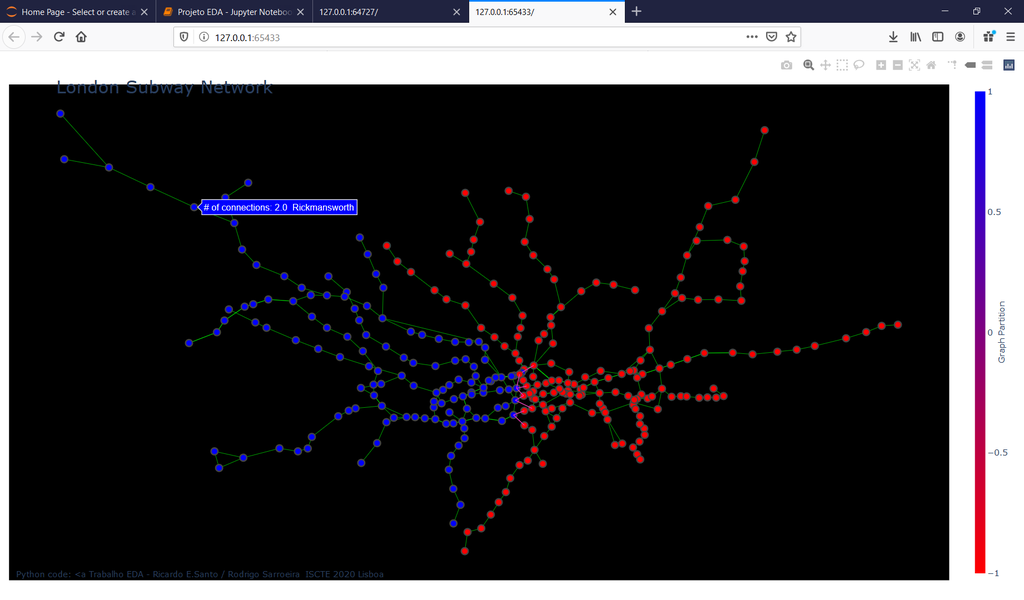

Figura 3 - Representação dos dois grafos separados.

Os círculos são a representação dos vértices do grafo, no nosso problema as estações de metro, e as linhas entre círculos as arestas as ligações entre estações. Com maior detalhe as arestas marcadas a cor-de-rosa as ligações cortadas no corte mínimo do grafo.

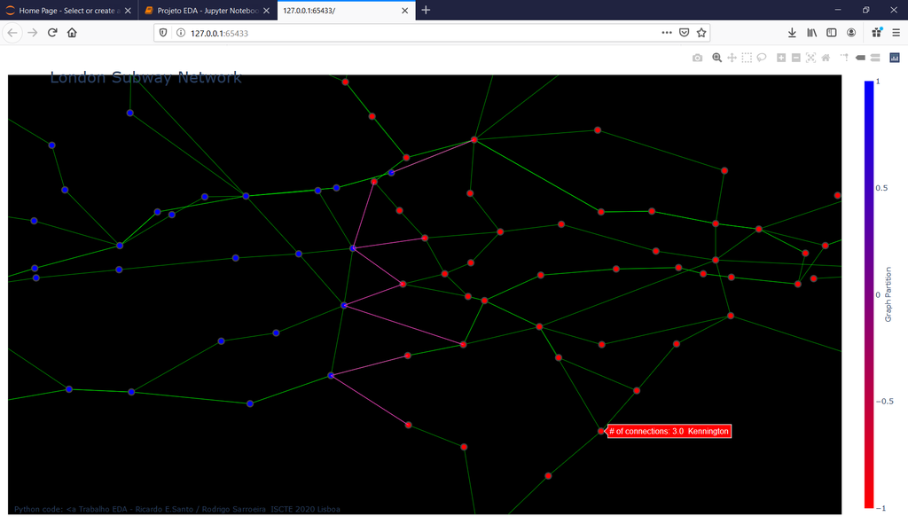

Figura 4 - Arestas a cortar para a divisão em dois do grafo.

Representação gráfica do caminho ótimo entre as estações Amersham e Wimbledon como resultado do algoritmo de Dijkstra.

[figure not shown]

Figura 5 - Caminho ótimo determinado.

## Discussão dos resultados obtidos

O algoritmo de bissecção espectral permite alcançar uma solução satisfatória, onde o valor do corte **c** é minimizado e o valor do produto das cardinalidades dos grafos criados de **|G1|x|G2|** é maximizado com valores próximos. Com isto o **ratio cut partition** **f** é minimizado. A complexidade temporal do algoritmo é **$O(n)$** na maioria das estruturas algumas funções com complexidade **$O(n^2)$** poderiam ser otimizadas. A visualização gráfica, apesar de não ser essencial para resolução, permite uma compreensão dos outputs do código e a sua validade.

No caso do caminho ótimo devido a falhas no ficheiro "Interstations v3.csv" não foi possível criar ligações entre vértices pertencentes da linha DLR. Esta falha pode ser verificada na figura 6. Para determinar o tempo ótimo foi necessário elaborar uma média entre tempos existentes entre estações. A solução apresentada aparenta cumprir todos os requesitos solicitados no enunciado do projeto.

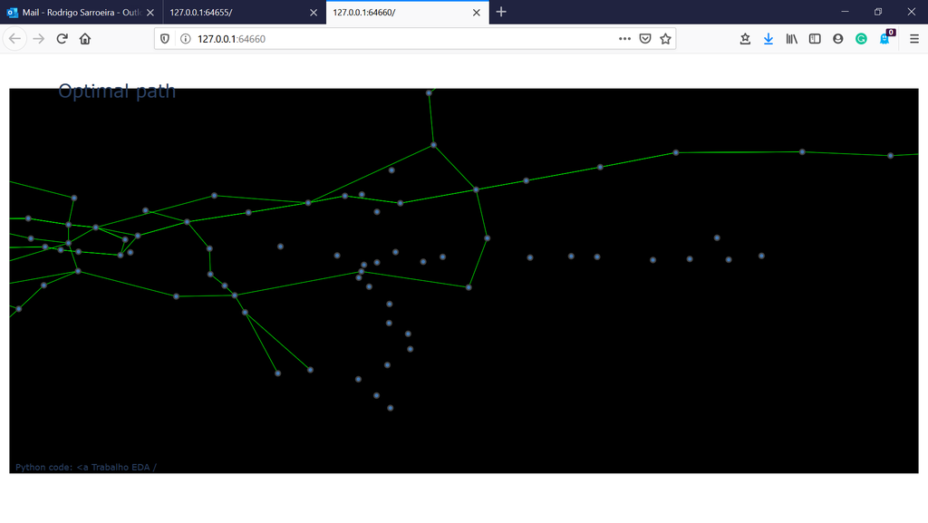

Figura 6 - Conexões ausentes da linha DLR

## Bibliografia

[1] Sniedovich, Moshe. (2006). Dijkstra's algorithm revisited: The dynamic programming connexion. Control and Cybernetics. 35. [2] Alex Pothen 1, Horst D. Simon 2, and Kang-Pu Paul Liu (July 1989) -Partitioning Sparse Matrices with Eigenvectors of Graphs, Report RNR-89-009,

[3] Elsner, Ulrich. (1999). - Graph Partitioning - A Survey. 1619-7186.

[4] Lars Hagen , Andrew B. KahngNew (1992) - Spectral methods for ratio cut partition and clustering

[5] U.C. Berkeley CS267 Home Page, Applications of Parallel Computers (1996) Graph Partitioning, Part 2 - https://people.eecs.berkeley.edu/~demmel/cs267/lecture20/lecture20.html

[6] William Fleshman(2019) - Towards Data Science, Spectral Clustering https://towardsdatascience.com/spectral-clustering-aba2640c0d5b